# Main Customer Segmentation

# Customer Segmentation using RFM Analysis (R)

**RFM (recency, frequency, monetary) analysis is a marketing technique used to determine quantitatively which customers are the best ones by examining**

- how recently a customer has purchased (recency),
- how often they purchase (frequency),
- and how much the customer spends (monetary).

https://help.synerise.com/use-cases/all-cases/_gfx/rfm1.png

Identifying the most valuable RFM segments can capitalize on chance relationships in the data used for this analysis.

# Load libraries :

```r
library(data.table)
library(dplyr)
library(ggplot2)
#library(stringr)
#library(DT)
library(tidyr)
library(knitr)
library(rmarkdown)
library(lubridate)
```

#Data Loading :

```r
#data <- read.csv("E:/Project/CustomerSegmentataion/data.csv")

data <- read.csv("D:/VisualStudioCode/R/CustomerSegmentationusingR/Project_1_Customer_Segmentation_using_R/Project_CustomerSegmentationUsingR/data.csv")
data
```

| InvoiceNo | StockCode | Description | Quantity | InvoiceDate | UnitPrice | CustomerID | Country |
| --- | --- | --- | --- | --- | --- | --- | --- |
| 536365 | 85123A | WHITE HANGING HEART T-LIGHT HOLDER | 6 | 12/01/2010 8:26 | 2.55 | 17850 | United Kingdom |
| 536365 | 71053 | WHITE METAL LANTERN | 6 | 12/01/2010 8:26 | 3.39 | 17850 | United Kingdom |
| 536365 | 84406B | CREAM CUPID HEARTS COAT HANGER | 8 | 12/01/2010 8:26 | 2.75 | 17850 | United Kingdom |
| 536365 | 84029G | KNITTED UNION FLAG HOT WATER BOTTLE | 6 | 12/01/2010 8:26 | 3.39 | 17850 | United Kingdom |
| 536365 | 84029E | RED WOOLLY HOTTIE WHITE HEART. | 6 | 12/01/2010 8:26 | 3.39 | 17850 | United Kingdom |
| 536365 | 22752 | SET 7 BABUSHKA NESTING BOXES | 2 | 12/01/2010 8:26 | 7.65 | 17850 | United Kingdom |
| 536365 | 21730 | GLASS STAR FROSTED T-LIGHT HOLDER | 6 | 12/01/2010 8:26 | 4.25 | 17850 | United Kingdom |
| 536366 | 22633 | HAND WARMER UNION JACK | 6 | 12/01/2010 8:28 | 1.85 | 17850 | United Kingdom |
| 536366 | 22632 | HAND WARMER RED POLKA DOT | 6 | 12/01/2010 8:28 | 1.85 | 17850 | United Kingdom |
| 536367 | 84879 | ASSORTED COLOUR BIRD ORNAMENT | 32 | 12/01/2010 8:34 | 1.69 | 13047 | United Kingdom |

[output cut: 990 more lines]

```r
data <- data.frame(data)
```

```r
summary(data)
```

```
   InvoiceNo        StockCode                                  Description
 573585 :  1114   85123A :  2313   WHITE HANGING HEART T-LIGHT HOLDER:  2369
 581219 :   749   22423  :  2203   REGENCY CAKESTAND 3 TIER          :  2200
 581492 :   731   85099B :  2159   JUMBO BAG RED RETROSPOT           :  2159
 580729 :   721   47566  :  1727   PARTY BUNTING                     :  1727
 558475 :   705   20725  :  1639   LUNCH BAG RED RETROSPOT           :  1638
 579777 :   687   84879  :  1502   ASSORTED COLOUR BIRD ORNAMENT     :  1501
 (Other):537202   (Other):530366   (Other)                           :530315
    Quantity                   InvoiceDate       UnitPrice           CustomerID
 Min.   :-80995.00   10/31/2011 14:41:  1114   Min.   :-11062.06   Min.   :12346
 1st Qu.:     1.00   12/08/2011 9:28 :   749   1st Qu.:     1.25   1st Qu.:13953
 Median :     3.00   12/09/2011 10:03:   731   Median :     2.08   Median :15152
 Mean   :     9.55   12/05/2011 17:24:   721   Mean   :     4.61   Mean   :15288
 3rd Qu.:    10.00   6/29/2011 15:58 :   705   3rd Qu.:     4.13   3rd Qu.:16791
 Max.   : 80995.00   11/30/2011 15:13:   687   Max.   : 38970.00   Max.   :18287
                     (Other)         :537202                       NA's   :135080
           Country
 United Kingdom:495478
 Germany       :  9495
 France        :  8557
 EIRE          :  8196
 Spain         :  2533
 Netherlands   :  2371
 (Other)       : 15279
```

# Data cleaning :

```r
glimpse(data)
```

```
Rows: 541,909
Columns: 8
$ InvoiceNo   <fct> 536365, 536365, 536365, 536365, 536365, 536365, 536365, 5363...
$ StockCode   <fct> 85123A, 71053, 84406B, 84029G, 84029E, 22752, 21730, 22633, ...
$ Description <fct> WHITE HANGING HEART T-LIGHT HOLDER, WHITE METAL LANTERN, CRE...
$ Quantity    <int> 6, 6, 8, 6, 6, 2, 6, 6, 6, 32, 6, 6, 8, 6, 6, 3, 2, 3, 3, 4,...
$ InvoiceDate <fct> 12/01/2010 8:26, 12/01/2010 8:26, 12/01/2010 8:26, 12/01/201...
$ UnitPrice   <dbl> 2.55, 3.39, 2.75, 3.39, 3.39, 7.65, 4.25, 1.85, 1.85, 1.69, ...
$ CustomerID  <int> 17850, 17850, 17850, 17850, 17850, 17850, 17850, 17850, 1785...
$ Country     <fct> United Kingdom, United Kingdom, United Kingdom, United Kingd...
```

checking NA values :

```r
sum(is.na(data))
```

```
[1] 135080
```

Removing Negative values from Quantity :

```r
data <- data %>% filter(Quantity>=0)
```

```r
sum(is.na(data))
```

```
[1] 133361
```

Filtering the Dataframe : Removing NA values

```r
data <- data %>% filter(!is.na(CustomerID))
```

```r
sum(is.na(data))
```

```
[1] 0
```

```r
#summary(data)
```

No of customer records :

```r
nrow(data)
```

```
[1] 397924
```

Number Of countries :

```r
length(unique(data$Country))
```

```
[1] 37
```

The custumers are from 37 different countries. Lets visualize this.

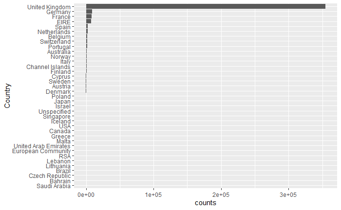

```r
#reorder the table and reset the factor to that ordering
data %>%
  group_by(Country) %>%                              # calculate the counts
  summarize(counts = n()) %>%
  arrange(counts) %>%                                # sort by counts
  mutate(Country = factor(Country, Country)) %>%     # reset factor
  ggplot(aes(x=Country, y=counts)) +                 # plot
    geom_bar(stat="identity") +                      # plot histogram
    coord_flip()                                     # flip the coordinates
```

The goods are shipped to 37 unique countries. The majority of goods is shipped to the United Kingdom. After the United Kingdom, Germany, France and EIRE (=Ireland) are the most important countries.

# Feature Engineering :

Make a new variable called TotalPrice, this variable gives the total price for each entry

```r
data$TotalPrice <- data$Quantity * data$UnitPrice
data
```

| InvoiceNo | StockCode | Description | Quantity | InvoiceDate | UnitPrice | CustomerID | Country | TotalPrice |
| --- | --- | --- | --- | --- | --- | --- | --- | --- |
| 536365 | 85123A | WHITE HANGING HEART T-LIGHT HOLDER | 6 | 12/01/2010 8:26 | 2.55 | 17850 | United Kingdom | 15.30 |
| 536365 | 71053 | WHITE METAL LANTERN | 6 | 12/01/2010 8:26 | 3.39 | 17850 | United Kingdom | 20.34 |
| 536365 | 84406B | CREAM CUPID HEARTS COAT HANGER | 8 | 12/01/2010 8:26 | 2.75 | 17850 | United Kingdom | 22.00 |
| 536365 | 84029G | KNITTED UNION FLAG HOT WATER BOTTLE | 6 | 12/01/2010 8:26 | 3.39 | 17850 | United Kingdom | 20.34 |
| 536365 | 84029E | RED WOOLLY HOTTIE WHITE HEART. | 6 | 12/01/2010 8:26 | 3.39 | 17850 | United Kingdom | 20.34 |
| 536365 | 22752 | SET 7 BABUSHKA NESTING BOXES | 2 | 12/01/2010 8:26 | 7.65 | 17850 | United Kingdom | 15.30 |
| 536365 | 21730 | GLASS STAR FROSTED T-LIGHT HOLDER | 6 | 12/01/2010 8:26 | 4.25 | 17850 | United Kingdom | 25.50 |
| 536366 | 22633 | HAND WARMER UNION JACK | 6 | 12/01/2010 8:28 | 1.85 | 17850 | United Kingdom | 11.10 |
| 536366 | 22632 | HAND WARMER RED POLKA DOT | 6 | 12/01/2010 8:28 | 1.85 | 17850 | United Kingdom | 11.10 |
| 536367 | 84879 | ASSORTED COLOUR BIRD ORNAMENT | 32 | 12/01/2010 8:34 | 1.69 | 13047 | United Kingdom | 54.08 |

[output cut: 990 more lines]

```r
NA
```

```r
#range
#range(data$InvoiceDate)
```

```r
data$InvoiceDateTime <- mdy_hm(data$InvoiceDate) #make datetime object
data$InvoiceDate <- ymd(date(data$InvoiceDateTime)) #make date variable
head(data)
```

|  | InvoiceNo | StockCode | Description | Quantity | InvoiceDate | UnitPrice | CustomerID | Country | TotalPrice | InvoiceDateTime |
| --- | --- | --- | --- | --- | --- | --- | --- | --- | --- | --- |
| 1 | 536365 | 85123A | WHITE HANGING HEART T-LIGHT HOLDER | 6 | 2010-12-01 | 2.55 | 17850 | United Kingdom | 15.30 | 2010-12-01 08:26:00 |
| 2 | 536365 | 71053 | WHITE METAL LANTERN | 6 | 2010-12-01 | 3.39 | 17850 | United Kingdom | 20.34 | 2010-12-01 08:26:00 |
| 3 | 536365 | 84406B | CREAM CUPID HEARTS COAT HANGER | 8 | 2010-12-01 | 2.75 | 17850 | United Kingdom | 22.00 | 2010-12-01 08:26:00 |
| 4 | 536365 | 84029G | KNITTED UNION FLAG HOT WATER BOTTLE | 6 | 2010-12-01 | 3.39 | 17850 | United Kingdom | 20.34 | 2010-12-01 08:26:00 |
| 5 | 536365 | 84029E | RED WOOLLY HOTTIE WHITE HEART. | 6 | 2010-12-01 | 3.39 | 17850 | United Kingdom | 20.34 | 2010-12-01 08:26:00 |
| 6 | 536365 | 22752 | SET 7 BABUSHKA NESTING BOXES | 2 | 2010-12-01 | 7.65 | 17850 | United Kingdom | 15.30 | 2010-12-01 08:26:00 |

```r
data$InvoiceYear <- year(data$InvoiceDate)
data$InvoiceMonth <- month(data$InvoiceDate,label=T)
data$InvoiceWeekday <- wday(data$InvoiceDate, label=T)
data$InvoiceHour <- hour(data$InvoiceDate)
#data
```

Here we have the number of transactions per month for 2011.

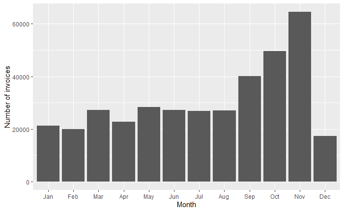

```r
timedata <- data %>%
  filter(InvoiceYear==2011) %>%
  count(InvoiceMonth)  #count the number of invoices per month for 2011

ggplot(timedata, aes(InvoiceMonth, n)) +  #plot the number of invoices per day
  geom_col() +
  labs(x="Month", y="Number of invoices")
```

It seems that the number of transactions is rising from September and the highest in November. In december the lowest number of transactions is performed.

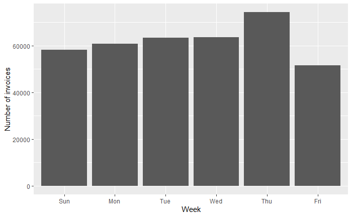

```r
timedata <- data %>%
  filter(InvoiceYear==2011) %>%
  count(InvoiceWeekday)

ggplot(timedata, aes(InvoiceWeekday, n)) +  #plot the number of invoices per day
    geom_col() +
  labs(x="Week", y="Number of invoices")
```

Most transactions are placed on monday, tuesday, wednesday and thursday.

```r
timedata <- data %>%
 filter(InvoiceYear==2011) %>%
  count(InvoiceHour)
#data
#ggplot(timedata, aes(InvoiceHour, n)) +  #plot the number of invoices per day
    #geom_col() +
  #labs(x="hour", y="Number of invoices")
#The most transactions are performed between 10 en 16:00 hours. At 12 hours the most transactions are performed.
#range(data$InvoiceYear)
```

##########################################################33

```r
retail <- data.frame(na.omit(data))
sum(is.na(retail))
```

```
[1] 0
```

```r
retail
```

|  | InvoiceNo | StockCode | Description | Quantity | InvoiceDate | UnitPrice | CustomerID | Country | TotalPrice | InvoiceDateTime | InvoiceYear | InvoiceMonth | InvoiceWeekday | InvoiceHour |
| --- | --- | --- | --- | --- | --- | --- | --- | --- | --- | --- | --- | --- | --- | --- |
| 1 | 536365 | 85123A | WHITE HANGING HEART T-LIGHT HOLDER | 6 | 2010-12-01 | 2.55 | 17850 | United Kingdom | 15.30 | 2010-12-01 08:26:00 | 2010 | Dec | Wed | 0 |
| 2 | 536365 | 71053 | WHITE METAL LANTERN | 6 | 2010-12-01 | 3.39 | 17850 | United Kingdom | 20.34 | 2010-12-01 08:26:00 | 2010 | Dec | Wed | 0 |
| 3 | 536365 | 84406B | CREAM CUPID HEARTS COAT HANGER | 8 | 2010-12-01 | 2.75 | 17850 | United Kingdom | 22.00 | 2010-12-01 08:26:00 | 2010 | Dec | Wed | 0 |
| 4 | 536365 | 84029G | KNITTED UNION FLAG HOT WATER BOTTLE | 6 | 2010-12-01 | 3.39 | 17850 | United Kingdom | 20.34 | 2010-12-01 08:26:00 | 2010 | Dec | Wed | 0 |
| 5 | 536365 | 84029E | RED WOOLLY HOTTIE WHITE HEART. | 6 | 2010-12-01 | 3.39 | 17850 | United Kingdom | 20.34 | 2010-12-01 08:26:00 | 2010 | Dec | Wed | 0 |
| 6 | 536365 | 22752 | SET 7 BABUSHKA NESTING BOXES | 2 | 2010-12-01 | 7.65 | 17850 | United Kingdom | 15.30 | 2010-12-01 08:26:00 | 2010 | Dec | Wed | 0 |
| 7 | 536365 | 21730 | GLASS STAR FROSTED T-LIGHT HOLDER | 6 | 2010-12-01 | 4.25 | 17850 | United Kingdom | 25.50 | 2010-12-01 08:26:00 | 2010 | Dec | Wed | 0 |
| 8 | 536366 | 22633 | HAND WARMER UNION JACK | 6 | 2010-12-01 | 1.85 | 17850 | United Kingdom | 11.10 | 2010-12-01 08:28:00 | 2010 | Dec | Wed | 0 |
| 9 | 536366 | 22632 | HAND WARMER RED POLKA DOT | 6 | 2010-12-01 | 1.85 | 17850 | United Kingdom | 11.10 | 2010-12-01 08:28:00 | 2010 | Dec | Wed | 0 |
| 10 | 536367 | 84879 | ASSORTED COLOUR BIRD ORNAMENT | 32 | 2010-12-01 | 1.69 | 13047 | United Kingdom | 54.08 | 2010-12-01 08:34:00 | 2010 | Dec | Wed | 0 |

[output cut: 990 more lines]

```r
retail$InvoiceDate <- as.Date(retail$InvoiceDate, '%m/%d/%Y %H:%M')
range(retail$InvoiceDate)
```

```
[1] "2010-12-01" "2011-12-09"
```

```r
summary(retail)
```

```
   InvoiceNo        StockCode                                  Description
 576339 :   542   85123A :  2035   WHITE HANGING HEART T-LIGHT HOLDER:  2028
 579196 :   533   22423  :  1724   REGENCY CAKESTAND 3 TIER          :  1724
 580727 :   529   85099B :  1618   JUMBO BAG RED RETROSPOT           :  1618
 578270 :   442   84879  :  1408   ASSORTED COLOUR BIRD ORNAMENT     :  1408
 573576 :   435   47566  :  1397   PARTY BUNTING                     :  1397
 567656 :   421   20725  :  1317   LUNCH BAG RED RETROSPOT           :  1316
 (Other):395022   (Other):388425   (Other)                           :388433
    Quantity         InvoiceDate           UnitPrice          CustomerID
 Min.   :    1.00   Min.   :2010-12-01   Min.   :   0.000   Min.   :12346
 1st Qu.:    2.00   1st Qu.:2011-04-07   1st Qu.:   1.250   1st Qu.:13969
 Median :    6.00   Median :2011-07-31   Median :   1.950   Median :15159
 Mean   :   13.02   Mean   :2011-07-10   Mean   :   3.116   Mean   :15294
 3rd Qu.:   12.00   3rd Qu.:2011-10-20   3rd Qu.:   3.750   3rd Qu.:16795
 Max.   :80995.00   Max.   :2011-12-09   Max.   :8142.750   Max.   :18287

           Country         TotalPrice        InvoiceDateTime
 United Kingdom:354345   Min.   :     0.00   Min.   :2010-12-01 08:26:00
 Germany       :  9042   1st Qu.:     4.68   1st Qu.:2011-04-07 11:12:00
 France        :  8342   Median :    11.80   Median :2011-07-31 14:39:00
 EIRE          :  7238   Mean   :    22.39   Mean   :2011-07-10 23:43:36
 Spain         :  2485   3rd Qu.:    19.80   3rd Qu.:2011-10-20 14:33:00
 Netherlands   :  2363   Max.   :168469.60   Max.   :2011-12-09 12:50:00
 (Other)       : 14109
  InvoiceYear    InvoiceMonth    InvoiceWeekday  InvoiceHour
 Min.   :2010   Nov    : 64545   Sun:62775      Min.   :0
 1st Qu.:2011   Oct    : 49557   Mon:64899      1st Qu.:0
 Median :2011   Dec    : 43464   Tue:66476      Median :0
 Mean   :2011   Sep    : 40030   Wed:68888      Mean   :0
 3rd Qu.:2011   May    : 28322   Thu:80052      3rd Qu.:0
 Max.   :2011   Jun    : 27185   Fri:54834      Max.   :0
                (Other):144821   Sat:    0
```

```r
retail <- subset(retail, InvoiceDate >= "2010-12-09")
range(retail$InvoiceDate)
```

```
[1] "2010-12-09" "2011-12-09"
```

```r
table(retail$Country)
```

```
           Australia              Austria              Bahrain              Belgium
                1163                  398                   17                 2019
              Brazil               Canada      Channel Islands               Cyprus
                  32                  151                  748                  614
      Czech Republic              Denmark                 EIRE   European Community
                  25                  380                 7106                   60
             Finland               France              Germany               Greece
                 685                 8164                 8838                  145
           Hong Kong              Iceland               Israel                Italy
                   0                  151                  248                  734
               Japan              Lebanon            Lithuania                Malta
                 305                   45                    0                  112
         Netherlands               Norway               Poland             Portugal
                2361                  925                  322                 1395
                 RSA         Saudi Arabia            Singapore                Spain
                  58                    9                  222                 2480
              Sweden          Switzerland United Arab Emirates       United Kingdom
                 451                 1836                   68               342478
         Unspecified                  USA
                 244                  179
```

```r
countries <- as.data.frame(table(retail$Country))
#countries
#names(countries)[names(countries) == 'Var1'] <- 'country'
#countries
#retail <- subset(retail, Country == "United Kingdom")
print("Invoice No ")
```

```
[1] "Invoice No "
```

```r
length(unique(retail$InvoiceNo))
```

```
[1] 17858
```

```r
print("Customer id")
```

```
[1] "Customer id"
```

```r
length(unique(retail$CustomerID))
```

```
[1] 4275
```

```r
# Identify returns
retail$item.return <- grepl("C", retail$InvoiceNo, fixed=TRUE)
retail$purchase.invoice <- ifelse(retail$item.return=="TRUE", 0, 1)
print("return ")
```

```
[1] "return "
```

```r
table(retail$item.return)
```

```
 FALSE
385168
```

```r
print("Purchase")
```

```
[1] "Purchase"
```

```r
table(retail$purchase.invoice)
```

```
     1
385168
```

```r
#retail
```

# RFM :

RECENCY - how recent did a customer bought something FREQUENCY - how often does a customer buy something MONETARY VALUE - what is the value of the purchased items

```r
customers <- as.data.frame(unique(retail$CustomerID))
names(customers) <- "CustomerID"
customers
```

| CustomerID |
| --- |
| 14243 |
| 12963 |
| 15513 |
| 15079 |
| 14437 |
| 15694 |
| 12942 |
| 15660 |
| 18092 |
| 15358 |

[output cut: 990 more lines]

2010/12/09 - 2011/12/09

consider current date is “01-01-2012”

```r
# Recency #
###########

#retail$recency <- as.Date("2011-12-10") - retail$InvoiceDate
#data$InvoiceDateTime <- mdy_hm(data$InvoiceDate) #make datetime variable
#data$InvoiceDate <- ymd(date(data$InvoiceDate)) #make date variable


data$Recency <-  as.numeric(mdy("01-01-2012") - data$InvoiceDate)
#data
r_data <- data %>%
  group_by(CustomerID) %>%
  summarize(Recency=min(Recency))

r_data
```

| CustomerID | Recency |
| --- | --- |
| 12346 | 348 |
| 12347 | 25 |
| 12348 | 98 |
| 12349 | 41 |
| 12350 | 333 |
| 12352 | 59 |
| 12353 | 227 |
| 12354 | 255 |
| 12355 | 237 |
| 12356 | 45 |

[output cut: 990 more lines]

```r
NA
```

Recency Recency was calculated as one of the features for the segmentation analysis. In this case recency has been calculated as follows, time of customer’s last purchase minus Latest date

```r
# Frequency #
#############

#customer.invoices <- subset(retail, select = c("CustomerID","InvoiceNo", "purchase.invoice"))

f_data <- data %>%
  group_by(CustomerID) %>%
  count(Frequency=n_distinct(InvoiceNo)) %>%
  mutate(Frequency > 0)%>%
  select(CustomerID, Frequency ) # Remove customers who have not made any purchases in the past year


#customers <- subset(f_data, Frequency > 0)

f_data
```

| CustomerID | Frequency |
| --- | --- |
| 12346 | 1 |
| 12347 | 7 |
| 12348 | 4 |
| 12349 | 1 |
| 12350 | 1 |
| 12352 | 8 |
| 12353 | 1 |
| 12354 | 1 |
| 12355 | 1 |
| 12356 | 3 |

[output cut: 990 more lines]

Frequency of Purchase Frequency was calculated counting the number of times a customer has made a transaction with the Online Retailer in a year. It is important to calculate the frequency of purchases, the online retailer wants it’s customers to buy as many times as possible, but the behavior of customers may be very different, some may a purchase a few times in bulk while other purchase low quantities frequently. The objective is to understand this behavior to serve them better.

```r
###############################
# Monetary Value of Customers #
###############################

# Total spent on each item on an invoice
#retail$Amount <- retail$Quantity * retail$UnitPrice
m_data <- data %>%
  group_by(CustomerID) %>%
  summarise(Monetary=sum(TotalPrice >0))

# Identify customers with negative monetary value numbers, as they were presumably returning purchases from the preceding year

m_data
```

| CustomerID | Monetary |
| --- | --- |
| 12346 | 1 |
| 12347 | 182 |
| 12348 | 31 |
| 12349 | 73 |
| 12350 | 17 |
| 12352 | 85 |
| 12353 | 4 |
| 12354 | 58 |
| 12355 | 13 |
| 12356 | 59 |

[output cut: 990 more lines]

```r
NA
```

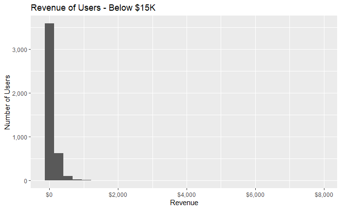

```r
MV_3Q <- m_data %>%
  filter( Monetary <= 15000)

MV_Outliers <- m_data %>%
  filter(Monetary > 15000)

# Visualizing a histogram of revenue generated by user
MV_3Q_Visz <- ggplot(MV_3Q, aes(Monetary)) +
  geom_histogram() +
  ggtitle('Revenue of Users - Below $15K') +
  ylab('Number of Users') +
  xlab('Revenue') +
  scale_x_continuous(labels = scales::dollar) +
  scale_y_continuous(labels = scales::comma)
print(MV_3Q_Visz)
```

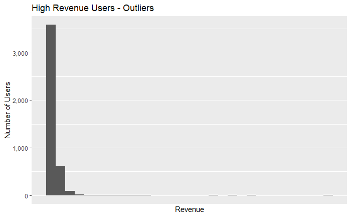

```r
# Visualizing histogram of Revenue Outliers
Outliers_Visz <- ggplot(m_data, aes(Monetary)) +
  geom_histogram() +
  ggtitle('High Revenue Users - Outliers') +
  ylab('Number of Users') +
  xlab('Revenue') +
  scale_x_continuous(labels = scales::dollar, breaks = c(50000, 100000, 150000, 200000, 250000, 300000, 350000)) +
  scale_y_continuous(labels = scales::comma)
print(Outliers_Visz)
```

Merging Recency, Frequency and Monetary Value. RFM Time to start merging the dataset for the cluster segmentation. So far, there has been three features constructed for the model. Recency, Frequency and Monetary Value of each customer. The three of these variables are now linked to the respective CustomerID.

Combine these the data sets r_data, f_data and m_data

```r
new_data <- r_data %>%
  full_join(m_data, by="CustomerID") %>%
  full_join(f_data, by="CustomerID")

new_data
```

| CustomerID | Recency | Monetary | Frequency |
| --- | --- | --- | --- |
| 12346 | 348 | 1 | 1 |
| 12347 | 25 | 182 | 7 |
| 12348 | 98 | 31 | 4 |
| 12349 | 41 | 73 | 1 |
| 12350 | 333 | 17 | 1 |
| 12352 | 59 | 85 | 8 |
| 12353 | 227 | 4 | 1 |
| 12354 | 255 | 58 | 1 |
| 12355 | 237 | 13 | 1 |
| 12356 | 45 | 59 | 3 |

[output cut: 990 more lines]

# Calculate RFM

**To implement the RFM analysis, we need to further process the data set in by the following steps:**

Now we have a new data set, containing four variables called 1) customerID, 2)Recency, 3)Monatory and 4) Frequency.

These four variables should be segmented in equal groups. Lets start with the first variable recency:

```r
#print(summary(customers$recency))
#kable(head(customers))

new_data$Recency_group <- cut(new_data$Recency,
                              quantile(new_data$Recency,
                              probs =seq(0,1,0.25)), #0 0.25 0.5 0.75 1
                              ordered_result=T,  #  should the result be an ordered factor?
                              include.lowest=T) # segment data into groups

new_data$Recency_group <- factor(new_data$Recency_group,
                                 labels=c("very recent", "recent", "old", "oldest")) # rename levels

new_data
```

| CustomerID | Recency | Monetary | Frequency | Recency_group |
| --- | --- | --- | --- | --- |
| 12346 | 348 | 1 | 1 | oldest |
| 12347 | 25 | 182 | 7 | very recent |
| 12348 | 98 | 31 | 4 | old |
| 12349 | 41 | 73 | 1 | recent |
| 12350 | 333 | 17 | 1 | oldest |
| 12352 | 59 | 85 | 8 | recent |
| 12353 | 227 | 4 | 1 | oldest |
| 12354 | 255 | 58 | 1 | oldest |
| 12355 | 237 | 13 | 1 | oldest |
| 12356 | 45 | 59 | 3 | recent |

[output cut: 990 more lines]

Now we can proceed with the variable called frequency. This variable will also be divided in four groups.

```r
table(new_data$Frequency)
```

```
   1    2    3    4    5    6    7    8    9   10   11   12   13   14   15   16   17
1494  835  508  387  243  172  143   98   68   54   52   45   30   20   28   11   18
  18   19   20   21   22   23   24   25   26   27   28   29   30   31   32   33   34
  14   12   12   11    5    5    3    8    7    3    6    1    4    3    3    2    3
  35   37   38   39   41   44   45   46   47   48   50   51   55   57   60   62   63
   1    3    2    2    1    1    1    1    2    1    1    1    2    1    1    1    1
  74   86   91   93   97  124  201  210
   1    1    1    1    1    1    1    1
```

```r
new_data$Frequency_group <- cut(new_data$Frequency,
                              c(0,1,3,10,188),
                              ordered_result=T) #segment into four groups

new_data$Frequency_group <- factor(new_data$Frequency_group,
                                 labels=c("very rare", "rare", "frequent", "very frequent"))

new_data
```

| CustomerID | Recency | Monetary | Frequency | Recency_group | Frequency_group |
| --- | --- | --- | --- | --- | --- |
| 12346 | 348 | 1 | 1 | oldest | very rare |
| 12347 | 25 | 182 | 7 | very recent | frequent |
| 12348 | 98 | 31 | 4 | old | frequent |
| 12349 | 41 | 73 | 1 | recent | very rare |
| 12350 | 333 | 17 | 1 | oldest | very rare |
| 12352 | 59 | 85 | 8 | recent | frequent |
| 12353 | 227 | 4 | 1 | oldest | very rare |
| 12354 | 255 | 58 | 1 | oldest | very rare |
| 12355 | 237 | 13 | 1 | oldest | very rare |
| 12356 | 45 | 59 | 3 | recent | rare |

[output cut: 990 more lines]

Now proceed with the monetary value

```r
#new_data$Monetary
new_data$Monetory_group <- cut(new_data$Monetary,
                              quantile(new_data$Monetary, probs=seq(0,1,0.25)),
                              ordered_result=T, include.lowest=T) #segment into groups

new_data$Monetory_group <- factor(new_data$Monetory_group,
                                 labels=c("small", "medium", "large", "very large")) #rename levels
new_data
```

| CustomerID | Recency | Monetary | Frequency | Recency_group | Frequency_group | Monetory_group |
| --- | --- | --- | --- | --- | --- | --- |
| 12346 | 348 | 1 | 1 | oldest | very rare | small |
| 12347 | 25 | 182 | 7 | very recent | frequent | very large |
| 12348 | 98 | 31 | 4 | old | frequent | medium |
| 12349 | 41 | 73 | 1 | recent | very rare | large |
| 12350 | 333 | 17 | 1 | oldest | very rare | small |
| 12352 | 59 | 85 | 8 | recent | frequent | large |
| 12353 | 227 | 4 | 1 | oldest | very rare | small |
| 12354 | 255 | 58 | 1 | oldest | very rare | large |
| 12355 | 237 | 13 | 1 | oldest | very rare | small |
| 12356 | 45 | 59 | 3 | recent | rare | large |

[output cut: 990 more lines]

# Visualize results

We now have segmented our customers in different groups. Lets visualize this:

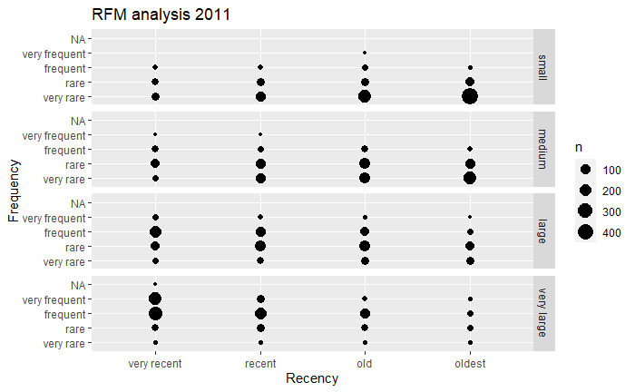

```r
ggplot(new_data, aes(Recency_group, Frequency_group)) +
  geom_count() +
  facet_grid(Monetory_group ~ .) + #If you have only one variable with many levels,
  labs(x="Recency", y="Frequency", title="RFM analysis 2011")
```

In this figure the Recency is put on the x-axis. Customers placed an order very recent, recent, less recent or not recent. Frequency is placed on the y-axis.

From the figure it can be observed, that customers that placed a recent order, were more likely to be frequent buyers and they were also more likely to spend a larger amount of money. When customers placed an order a long time ago, they were more likely to place only one or a few orders and they were also more likely to spend a small amount of money.

This information could be helpfull to target specific groups of customers.

# Statistical Clustering - KMeans

```r
# Creating Clusters based on the RFM Table using Unsupervised Statistical Learning
set.seed(2020)
clusters <- kmeans(scale(new_data[,2:4]), 3, nstart = 1) # Performing kmeans with RFM variables and creating 3 clusters.

new_data$Cluster <- as.factor(clusters$cluster) # Attaching the results to CustomersID to identify each customer's cluster
```

[output not shown]

```r
KMeans_Results <- new_data %>%
  group_by(Cluster) %>%
  summarise('Number of Users' = n(),
            'Recency Mean' = round(mean(Recency)),
            'Frequency Mean' = scales::comma(round(mean(Frequency))),
            'Monetary Value Mean' = scales::dollar(round(mean(Monetary))),
            'Cluster Revenue' = scales::dollar(sum(Monetary))
            )
KMeans_Results
```

[output not shown]

[figure not shown]